# CSCI E-63C Week 10 assignment

# Introduction

In this assignment we will compare performance of random forest to that of LDA and KNN on a simulated dataset where we know exactly what is the association between predictors and outcome. The relationship between predictor levels and the outcome will involve interaction that is notoriously difficult to model by methods such as LDA. The following example below illustrates the main ideas on a 3D dataset with two of the three attributes associated with the outcome:

```r
# How many observations:
nObs <- 1000
# How many predictors are associated with outcome:
nClassVars <- 2
# How many predictors are not:
nNoiseVars <- 1
# To modulate average difference between two classes' predictor values:
deltaClass <- 1
# Simulate dataset with interaction between attribute levels associated with the outcome:
xyzTmp <- matrix(rnorm(nObs*(nClassVars+nNoiseVars)),nrow=nObs,ncol=nClassVars+nNoiseVars)
classTmp <- 1
for ( iTmp in 1:nClassVars ) {
  deltaTmp <- sample(deltaClass*c(-1,1),nObs,replace=TRUE)
  xyzTmp[,iTmp] <- xyzTmp[,iTmp] + deltaTmp
  classTmp <- classTmp * deltaTmp
}
classTmp <- factor(classTmp > 0)
table(classTmp)
```

```
## classTmp
## FALSE  TRUE
##   487   513
```

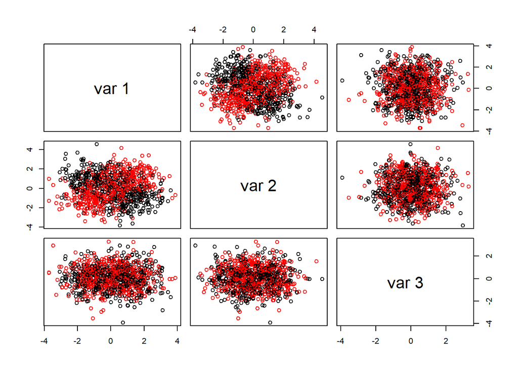

```r
# plot resulting attribute levels colored by outcome:
pairs(xyzTmp,col=as.numeric(classTmp))
```

We can see that it is the interaction between the first two variables that has influences the outcome (we simulated it this way, of course!) and that points belonging to each of the two classes cannot be readily separated by a single line in 2D (or a single surface in 3D).

```r
# Split data into train and test
bTrain <- sample(c(FALSE,TRUE),nrow(xyzTmp),replace=TRUE)
# Fit random forest to train data, obtain test error:
rfRes <- randomForest(xyzTmp[bTrain,],classTmp[bTrain])
rfTmpTbl <- table(classTmp[!bTrain],predict(rfRes,newdata=xyzTmp[!bTrain,]))
rfTmpTbl
```

```
##
##         FALSE TRUE
##   FALSE   152   93
##   TRUE     55  184
```

Random forest seems to do reasonably well on such dataset.

```r
# Fit LDA model to train data and evaluate error on the test data:
ldaRes <- lda(xyzTmp[bTrain,],classTmp[bTrain])
ldaTmpTbl <- table(classTmp[!bTrain],predict(ldaRes,newdata=xyzTmp[!bTrain,])$class)
ldaTmpTbl
```

```
##
##         FALSE TRUE
##   FALSE    73  172
##   TRUE     45  194
```

LDA, on the other hand, not so good! (not a surprise given what we’ve seen above). What about a more flexible method such a KNN? Let’s check it out remembering that k – number of neihbors – in KNN is the parameter to modulate its flexibility (i.e. bias-variance tradeoff).

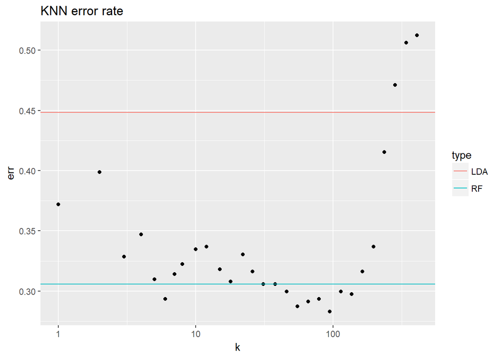

```r
# Fit KNN model at several levels of k:

dfTmp <- NULL
for ( kTmp in sort(unique(floor(1.2^(1:33)))) ) {
  knnRes <- knn(xyzTmp[bTrain,],xyzTmp[!bTrain,],classTmp[bTrain],k=kTmp)
  tmpTbl <- table(classTmp[!bTrain],knnRes)
  dfTmp <- rbind(dfTmp,data.frame(err=1-sum(diag(tmpTbl))/sum(tmpTbl),k=kTmp))
}
ggplot(dfTmp,aes(x=k,y=err))+geom_point()+scale_x_log10()+geom_hline(aes(yintercept = err,colour=type),data=data.frame(type=c("LDA","RF"),err=c(1-sum(diag(ldaTmpTbl))/sum(ldaTmpTbl),1-sum(diag(rfTmpTbl))/sum(rfTmpTbl))))+ggtitle("KNN error rate")
```

We can see from the above that there is a range of $K$ values where test error of KNN is the lowest and it is even lower that that of RF. Now would be a good moment to think why one would want to choose RF over KNN or vice a versa for modeling the data if the figure above was representative of their true relative performance on a new dataset.

For the purposes of the assignment you can use the code above (probably best to wrap reusable parts of it into function(s)) to generate data with varying numbers of predictors associated with outcome and not, different numbers of observations and differences in the average values of predictors’ between two classes as required below. These differences between datasets and parameters of the call to random forest will illustrate some of the factors influencing relative performance of random forest, LDA and KNN classifiers. When comparing to KNN performance, please choose value(s) of `k` such that it performs sufficiently well – feel free to refer to the plot above to select useful value(s) of `k` that you would like to evaluate here. Keep in mind also that the value of `k` cannot be larger than the number of observations in the training dataset.

# Sub-problem 1 (15 points): effect of sample size

Generate training datasets with `nObs=25`, `100` and `500` observations such that two variables are associated with the outcome as parameterized above and three are not associated and average difference between the two classes is the same as above (i.e. in the notation from the above code `nClassVars=2`, `nNoiseVars=3` and `deltaClass=1`). Obtain random forest, LDA and KNN test error rates on a (for greater stability of the results, much larger, say, with 10K observations) test dataset simulated from the same model. Describe the differences between different methods and across the sample sizes used here.

> Generate training datasets with `nObs=25`, `100` and `500` observations such that two variables are associated with the outcome as parameterized above and three are not associated and average difference between the two classes is the same as above (i.e. in the notation from the above code `nClassVars=2`, `nNoiseVars=3` and `deltaClass=1`).

Generate three training sets with number of observations = `25`/`100`/`500`

```r
# nClassVars: How many predictors are associated with outcome:
# nNoiseVars: How many predictors are not:
# deltaClass: To modulate average difference between two classes' predictor values:
sim_data = function(nObs=1000, nClassVars=2, nNoiseVars=1, deltaClass=1){
  set.seed(63)
  # Simulate dataset with interaction between attribute levels associated with the outcome:
  xyzTmp = matrix(rnorm(nObs*(nClassVars+nNoiseVars)),nrow=nObs,ncol=nClassVars+nNoiseVars)
  classTmp = 1
  for ( iTmp in 1:nClassVars ) {
    deltaTmp = sample(deltaClass*c(-1,1), nObs,replace=TRUE)
    xyzTmp[,iTmp] = xyzTmp[,iTmp] + deltaTmp
    classTmp = classTmp * deltaTmp
  }
  classTmp = factor(classTmp > 0)

  # return data.frame with class as first column = 'y_class'
  return(data.frame(y_class=classTmp, xyzTmp))
  #return (cbind(classTmp, xyzTmp))
}

train_25 = sim_data(nObs=25, nClassVars=2, nNoiseVars=3, deltaClass=1)
train_100 = sim_data(nObs=100, nClassVars=2, nNoiseVars=3, deltaClass=1)
train_500 = sim_data(nObs=500, nClassVars=2, nNoiseVars=3, deltaClass=1)
```

Check the results to make sure everything as expected, first a `table` to demonstrate approximate 50/50 distribution of outcome variable = `y_class`. Then pair-wise plots to show we have two “associated” variables (`X1`, `X2`) along with three independent (`X3`,`X4`,`X5`), for a total of five predictor variables.

```r
# sanity check on the training set of 500 observations
table(train_500[,1])
```

```
##
## FALSE  TRUE
##   245   255
```

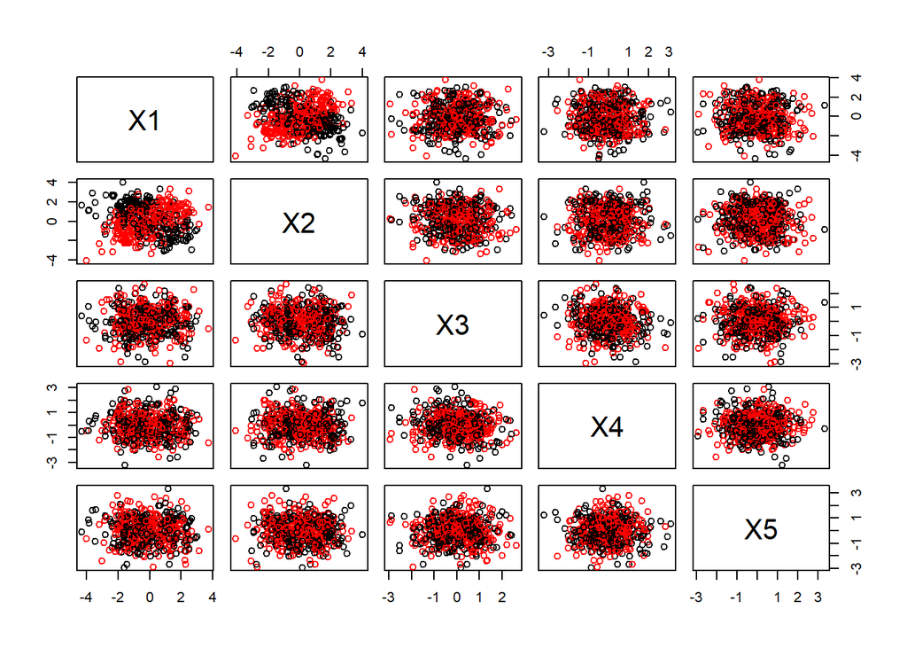

```r
# plot resulting attribute levels colored by outcome:
pairs(train_500[,-1], col=as.numeric(train_500[,1]))
```

> Obtain random forest, LDA and KNN test error rates on a (for greater stability of the results, much larger, say, with 10K observations) test dataset simulated from the same model.

Create functions for fitting and calculating error rate on the Random Forest, LDA, and KNN

```r
err_rate = function(tbl) {
  return (1-sum(diag(tbl))/sum(tbl))
}

rf_predict_table = function (train, test, mtry_val=0) {
  # y_class outcome variable is in first column
  if (mtry_val == 0) {
    rf_fit = randomForest(train[,-1], train[,1])
  } else {
      print(paste0('mtry passed in = ', mtry_val))
      rf_fit = randomForest(train[,-1], train[,1], mtry=mtry_val)
  }
  rf_pred_table = table(test[,1],predict(rf_fit, newdata=test[,-1]))
  rf_err_rate = err_rate(rf_pred_table)

  list(conf_table=rf_pred_table, err_rate=rf_err_rate)
}

lda_predict_table = function(train, test) {
  lda_fit = lda(train[,-1], train[,1])
  lda_pred_table = table(test[,1], predict(lda_fit, newdata=test[,-1])$class)
  lda_err_rate = err_rate(lda_pred_table)

  list(conf_table=lda_pred_table, err_rate=lda_err_rate)
}

knn_predict_multiple = function(train, test, knn_range=1:10) {
  df_knn = NULL
  for ( kTmp in knn_range) {
    if (kTmp > nrow(data.frame(train)) ) {
      # if k > number of observations, skip
      next
    }
    knn_fit = knn(data.frame(train[,-1]), data.frame(test[,-1]), train[,1], k=kTmp)
    tmp_tbl = table(test[,1], knn_fit)
    df_knn = rbind(df_knn, data.frame(err=err_rate(tmp_tbl), k=kTmp))
  }
  return (df_knn)
}
```

### Sanity check

Run the original test/train used for the final plot in the *Introduction* through my new functions and confirm both the original plot, and the one below, look similar.

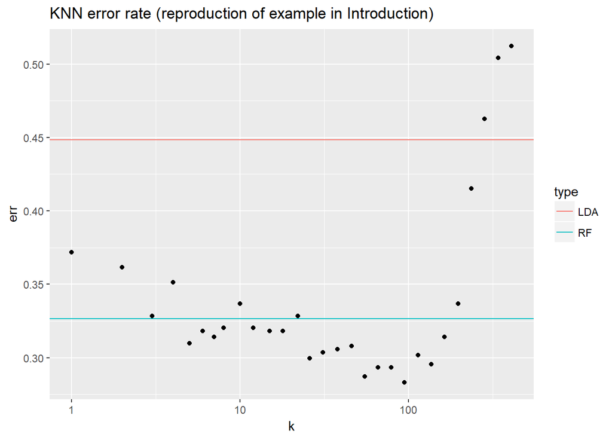

```r
df_repro_train = data.frame(classTmp[bTrain], xyzTmp[bTrain,])
df_repro_test = data.frame(classTmp[!bTrain], xyzTmp[!bTrain,])

lda_predict_repro = lda_predict_table(df_repro_train, df_repro_test)
lda_tmp_tbl_repro = lda_predict_repro$conf_table
lda_error_repro = lda_predict_repro$err_rate
rf_predict_repro = rf_predict_table(df_repro_train, df_repro_test)
rf_tmp_tbl_repro = rf_predict_repro$conf_table
rf_error_repro = rf_predict_repro$err_rate


rng = sort(unique(floor(1.2^(1:33))))
df_knn_repro = knn_predict_multiple(df_repro_train, df_repro_test, knn_range=rng)

ggplot(df_knn_repro,aes(x=k,y=err))+geom_point()+scale_x_log10()+geom_hline(aes(yintercept = err,colour=type),data=data.frame(type=c("LDA","RF"),err=c(lda_error_repro, rf_error_repro)))+ggtitle("KNN error rate (reproduction of example in Introduction)")
```

Results are good, it appears I didn’t make any blatant errors in turning the ad-hoc code into functions.

### Continuing…

Generate a 10k test dataset with same params as for the training sets.

```r
test = sim_data(nObs=10000, nClassVars=2, nNoiseVars=3, deltaClass=1)
```

Calculate Random Forest and LDA using each of the three training set sizes + test dataset = 10,000 rows. Print out the associated confusion matrix and error rate for each.

```r
rf_25 = rf_predict_table(train_25, test)
rf_100 = rf_predict_table(train_100, test)
rf_500 = rf_predict_table(train_500, test)

lda_25 = lda_predict_table(train_25, test)
lda_100 = lda_predict_table(train_100, test)
lda_500 = lda_predict_table(train_500, test)

n=25
cat(sprintf('nObs=%s training set\n', n))
```

```
## nObs=25 training set
```

```r
cat('* Random Forest\n')
```

```
## * Random Forest
```

```r
rf_25
```

```
## $conf_table
##
##         FALSE TRUE
##   FALSE  2275 2707
##   TRUE   1937 3081
##
## $err_rate
## [1] 0.4644
```

```r
cat('* LDA\n')
```

```
## * LDA
```

```r
lda_25
```

```
## $conf_table
##
##         FALSE TRUE
##   FALSE  2329 2653
##   TRUE   2248 2770
##
## $err_rate
## [1] 0.4901
```

```r
n=100
cat(sprintf('nObs=%s training set\n', n))
```

```
## nObs=100 training set
```

```r
cat('* Random Forest\n')
```

```
## * Random Forest
```

```r
rf_100
```

```
## $conf_table
##
##         FALSE TRUE
##   FALSE  3134 1848
##   TRUE   1777 3241
##
## $err_rate
## [1] 0.3625
```

```r
cat('* LDA\n')
```

```
## * LDA
```

```r
lda_100
```

```
## $conf_table
##
##         FALSE TRUE
##   FALSE  2673 2309
##   TRUE   2792 2226
##
## $err_rate
## [1] 0.5101
```

```r
n=500
cat(sprintf('nObs=%s training set\n', n))
```

```
## nObs=500 training set
```

```r
cat('* Random Forest\n')
```

```
## * Random Forest
```

```r
rf_500
```

```
## $conf_table
##
##         FALSE TRUE
##   FALSE  3084 1898
##   TRUE   1239 3779
##
## $err_rate
## [1] 0.3137
```

```r
cat('* LDA\n')
```

```
## * LDA
```

```r
lda_500
```

```
## $conf_table
##
##         FALSE TRUE
##   FALSE  2065 2917
##   TRUE   2095 2923
##
## $err_rate
## [1] 0.5012
```

Random Forest, error rates on `nObs=10k` test set, with model based on:  
* `nObs=25` train set : 0.4644  
* `nObs=100` train set : 0.3625  
* `nObs=500` train set : 0.3137

LDA, error rates on `nObs=10k` test set, with model based on:  
* `nObs=25` train set : 0.4901  
* `nObs=100` train set : 0.5101  
* `nObs=500` train set : 0.5012

Trying similar outputs for `knn` would be a little extreme, given the number of $k$ values that will be used. So we are going to settle on a broad visualization of `knn` error rates and also add in the various rates for both Random Forest and LDA.

```r
get_err_plot = function(df, lda_err_rate, rf_err_rate, title_suffix) {
  # if more than one, return the first row
  lowest_err_row = df[which(df$err==min(df$err)),][1,]
  lowest_err_value = round(lowest_err_row$err, 4)
  lowest_err_k = lowest_err_row$k
  lowest_err_label = sprintf('lowest err:\n%f\nk=%d', lowest_err_row$err, lowest_err_k)

  plt = (ggplot(df,aes(x=k,y=err))
         + geom_point()
  #       + scale_x_log10()
    + scale_x_log10(breaks=sort(c(round(seq(min(df$k), max(df$k), length.out=10)), lowest_err_k)))
         + geom_hline(aes(yintercept=err, colour=type),
                      data=data.frame(type=c("LDA","RF"),
                      err=c(lda_err_rate, rf_err_rate)))

         + geom_text(aes(1, err, colour=type, label=err_rate_label, vjust = -1),
                      data=data.frame(type=c("LDA","RF"),
                        err_rate_label=c(lda_err_rate, rf_err_rate),
                        err=c(lda_err_rate, rf_err_rate)))

         #+ geom_text(aes(1, lda_err_rate, label=lda_err_rate, vjust = -1))
         #+ geom_text(aes(1, rf_err_rate, label=rf_err_rate, vjust = -1))
         + geom_text(aes(lowest_err_k, lowest_err_value, label=lowest_err_label, vjust=-1))
         + geom_text(aes(lowest_err_k, lowest_err_value, label='|', vjust=-3))
         + ggtitle(sprintf('KNN, LDA, RF error rates, %s ', title_suffix)))

  return (list(g_plot=plt, err_info=lowest_err_row))
}

# testing of above
rng = sort(unique(floor(1.2^(1:26))))
df_knn_train_100 = knn_predict_multiple(train_100, test, knn_range=rng)
out = get_err_plot(df_knn_train_100, lda_100$err_rate, rf_100$err_rate, 'TESTING ** TESTING')
# out$g_plot
```

First plot is for all three models where the training set size = **25**

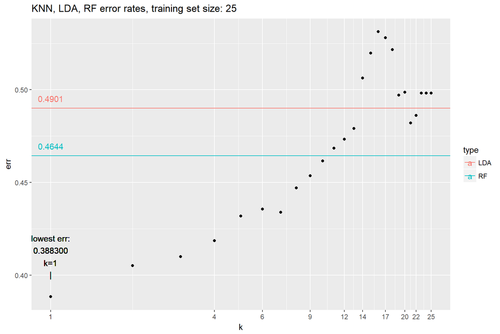

```r
# put in a reasonable range for this training dataset
#  though it will effectivley exit once k > number of training observations
rng = 1:25
df_knn_train_25 = knn_predict_multiple(train_25, test, knn_range=rng)

# norm_scale_plt_test = (ggplot(df_knn_train_25,aes(x=k,y=err))
#        + geom_point()
#        + scale_x_continuous(breaks=df_knn_train_25$k)
#        + geom_hline(aes(yintercept = err, colour=type), data=data.frame(type=c("LDA","RF"),err=c(lda_25$err_rate, rf_25$err_rate)))
#        + geom_text(aes(0, lda_25$err_rate, label=lda_25$err_rate, vjust = -1))
#        + geom_text(aes(0, rf_25$err_rate, label=rf_25$err_rate, vjust = -1))
#        + ggtitle('KNN, LDA, RF error rates, training set size: 25'))

# use the function instead
out_25 = get_err_plot(df_knn_train_25, lda_25$err_rate, rf_25$err_rate,
  sprintf('training set size: %d', 25))
out_25$g_plot
```

At a very low training set size of 25, KNN is the obvious winner, where there are multiple $K$ values that result in a lower error rate than either LDA or Random Forest, with lowest actually at $K$=1. Looks like anything < 11 or so will beat the model with the next lowest error rate = Random Forest. Bringing up the rear would be LDA, which has the highest error rate (not considering KNN with $K$ > ~14).

Next, training set size = **100**

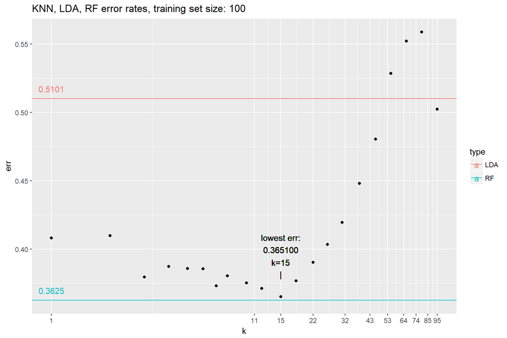

```r
rng = sort(unique(floor(1.2^(1:26))))
df_knn_train_100 = knn_predict_multiple(train_100, test, knn_range=rng)
out_100 = get_err_plot(df_knn_train_100, lda_100$err_rate, rf_100$err_rate,
  sprintf('training set size: %d', 100))
out_100$g_plot
```

And finally training set size = **500**

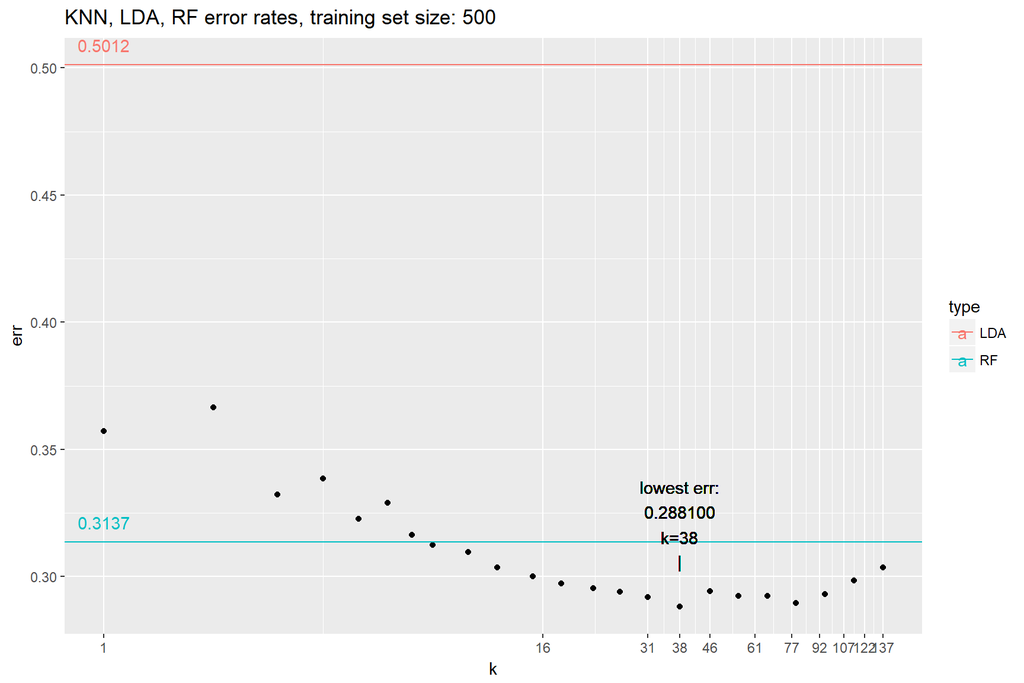

```r
rng = sort(unique(floor(1.2^(1:27))))
df_knn_train_500 = knn_predict_multiple(train_500, test, knn_range=rng)

out_500 = get_err_plot(df_knn_train_500, lda_500$err_rate, rf_500$err_rate,
  sprintf('training set size: %d', 500))
out_500$g_plot
```

With a 500 member training set LDA produces the model with the highest error rate once more. The lowest is KNN with $K$=38 and there are several $K$ values that generate a lower value than the remaining method = Random Forest. Even so, Random Forest and those multiple low-error-rate KNN are around the same level, which is notably lower than LDA.

> Describe the differences between different methods and across the sample sizes used here.

Above included descriptions of the differences betwen the various methods. In terms of differing sample sizes, error rate on LDA went up a very little bit and then back down again as the sample size increased, which could have just been due to natural variability with little real meaning. Random Forest consistently produced a lower error rate as sample size increase, with the biggest relative jump coming from the increase 25 -> 100 training set. KNN followed a similar pattern, decreasing error rate as training size increased, but the change wasn’t as evident as for Random Forest.

# Sub-problem 2 (15 points): effect of signal magnitude

For training datasets with `nObs=100` and `500` observations simulate data as shown above with average differences between the two classes that are same as above, half of that and twice that (i.e. `deltaClass=0.5`, `1` and `2`). Obtain and plot test error rates of random forest, LDA and KNN for each of the six (two samples sizes times three signal magnitudes) combinations of sample size and signal strengths. As before use large test dataset (e.g. 10K observations or so) for greater stability of the results. Describe the most pronounced differences across error rates for those datasets: does the increase in the number of observations impact the error rate of the models? Does change in the magnitude of signal impact their performance? Are different classifier approaches impacted in a similar way?

> For training datasets with `nObs=100` and `500` observations simulate data as shown above with average differences between the two classes that are same as above, half of that and twice that (i.e. `deltaClass=0.5`, `1` and `2`).

Create training and test datasets, create the Random Forest and LDA models

```r
train_100_delta_a = sim_data(nObs=100, nClassVars=2, nNoiseVars=3, deltaClass=0.5)
train_500_delta_a = sim_data(nObs=500, nClassVars=2, nNoiseVars=3, deltaClass=0.5)
test_delta_a = sim_data(nObs=10000, nClassVars=2, nNoiseVars=3, deltaClass=0.5)

# generate new sets to keep naming conventions consistent
train_100_delta_b = sim_data(nObs=100, nClassVars=2, nNoiseVars=3, deltaClass=1)
train_500_delta_b = sim_data(nObs=500, nClassVars=2, nNoiseVars=3, deltaClass=1)
test_delta_b = sim_data(nObs=10000, nClassVars=2, nNoiseVars=3, deltaClass=1)

train_100_delta_c = sim_data(nObs=100, nClassVars=2, nNoiseVars=3, deltaClass=2)
train_500_delta_c = sim_data(nObs=500, nClassVars=2, nNoiseVars=3, deltaClass=2)
test_delta_c = sim_data(nObs=10000, nClassVars=2, nNoiseVars=3, deltaClass=2)
```

> Obtain and plot test error rates of random forest, LDA and KNN for each of the six (two samples sizes times three signal magnitudes) combinations of sample size and signal strengths. As before use large test dataset (e.g. 10K observations or so) for greater stability of the results.

Create and display results for training set of `nObs`=100, `delta`=0.5

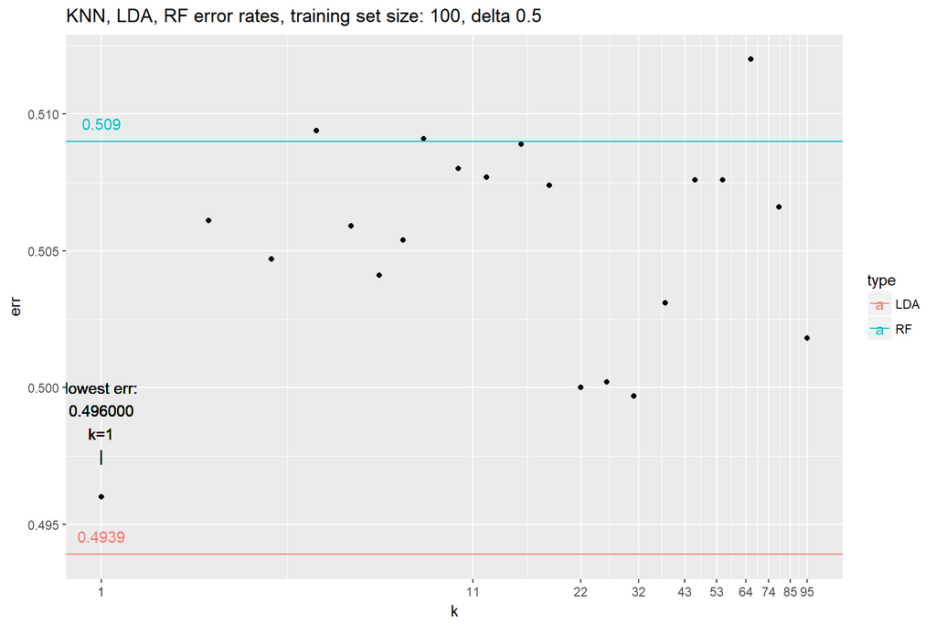

```r
rf_100_delta_a = rf_predict_table(train_100_delta_a, test_delta_a)
lda_100_delta_a = lda_predict_table(train_100_delta_a, test_delta_a)

rng = sort(unique(floor(1.2^(1:26))))
df_knn_train_100_delta_a = knn_predict_multiple(train_100_delta_a, test_delta_a, knn_range=rng)
out = get_err_plot(df_knn_train_100_delta_a, rf_100_delta_a$err_rate, lda_100_delta_a$err_rate,
  sprintf('training set size: %d, delta %.1f', 100, 0.5))
knn_train_100_delta_a_err_info=out$err_info
out1=out
out$g_plot
```

Create and display results for training set of `nObs`=500, `delta`=0.5

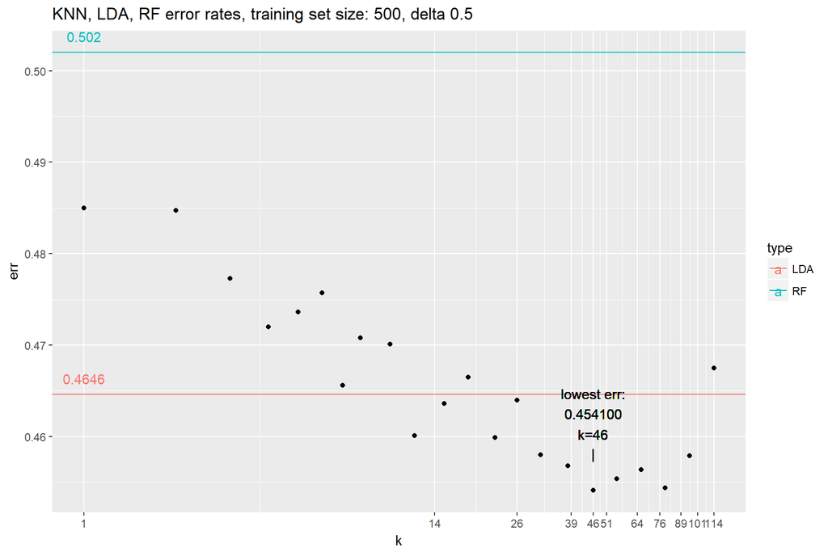

```r
rf_500_delta_a = rf_predict_table(train_500_delta_a, test_delta_a)
lda_500_delta_a = lda_predict_table(train_500_delta_a, test_delta_a)

rng = sort(unique(floor(1.2^(1:26))))
df_knn_train_500_delta_a = knn_predict_multiple(train_500_delta_a, test_delta_a, knn_range=rng)
out = get_err_plot(df_knn_train_500_delta_a, rf_500_delta_a$err_rate, lda_500_delta_a$err_rate,
  sprintf('training set size: %d, delta %.1f', 500, 0.5))
knn_train_500_delta_a_err_info=out$err_info
out2=out
out$g_plot
```

Create and display results for training set of `nObs`=100, `delta`=1

[figure not shown]

```r
rf_100_delta_b = rf_predict_table(train_100_delta_b, test_delta_b)
rf_500_delta_b = rf_predict_table(train_500_delta_b, test_delta_b)
lda_100_delta_b = lda_predict_table(train_100_delta_b, test_delta_b)
lda_500_delta_b = lda_predict_table(train_500_delta_b, test_delta_b)

rng = sort(unique(floor(1.2^(1:26))))
df_knn_train_100_delta_b = knn_predict_multiple(train_100_delta_b, test_delta_b, knn_range=rng)
out = get_err_plot(df_knn_train_100_delta_b, rf_100_delta_b$err_rate, lda_100_delta_b$err_rate,
  sprintf('training set size: %d, delta %.1f', 100, 1))
knn_train_100_delta_b_err_info=out$err_info
out3=out
out$g_plot
```

Create and display results for training set of `nObs`=500, `delta`=1

[figure not shown]

```r
rf_500_delta_b = rf_predict_table(train_500_delta_b, test_delta_b)
lda_500_delta_b = lda_predict_table(train_500_delta_b, test_delta_b)

rng = sort(unique(floor(1.2^(1:26))))
df_knn_train_500_delta_b = knn_predict_multiple(train_500_delta_b, test_delta_b, knn_range=rng)
out = get_err_plot(df_knn_train_500_delta_b, rf_500_delta_b$err_rate, lda_500_delta_b$err_rate,
  sprintf('training set size: %d, delta %.1f', 500, 1))
knn_train_500_delta_b_err_info=out$err_info
out4=out
out$g_plot
```

Create and display results for training set of `nObs`=100, `delta`=2

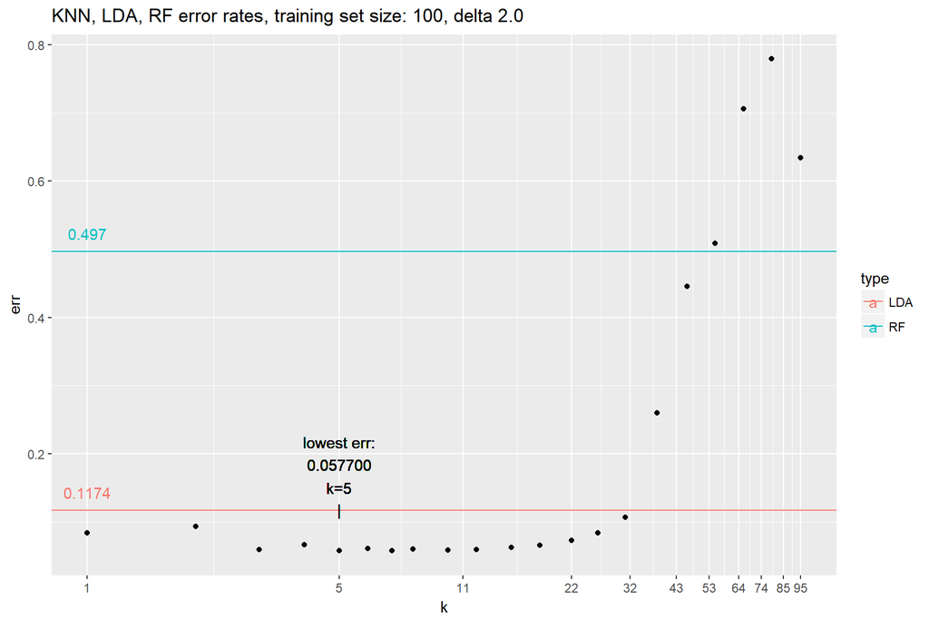

```r
rf_100_delta_c = rf_predict_table(train_100_delta_c, test_delta_c)
lda_100_delta_c = lda_predict_table(train_100_delta_c, test_delta_c)

rng = sort(unique(floor(1.2^(1:26))))
df_knn_train_100_delta_c = knn_predict_multiple(train_100_delta_c, test_delta_c, knn_range=rng)
out = get_err_plot(df_knn_train_100_delta_c, rf_100_delta_c$err_rate, lda_100_delta_c$err_rate,
  sprintf('training set size: %d, delta %.1f', 100, 2))
knn_train_100_delta_c_err_info=out$err_info
out5=out
out$g_plot
```

Create and display results for training set of `nObs`=500, `delta`=2

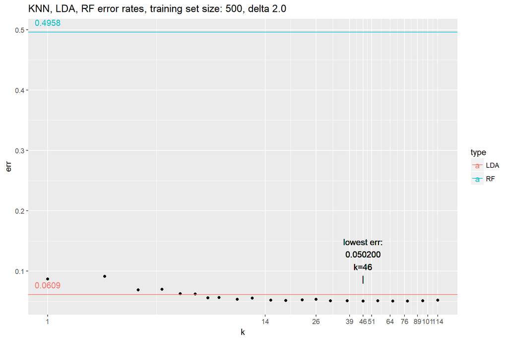

```r
rf_500_delta_c = rf_predict_table(train_500_delta_c, test_delta_c)
lda_500_delta_c = lda_predict_table(train_500_delta_c, test_delta_c)

rng = sort(unique(floor(1.2^(1:26))))
df_knn_train_500_delta_c = knn_predict_multiple(train_500_delta_c, test_delta_c, knn_range=rng)
out = get_err_plot(df_knn_train_500_delta_c, rf_500_delta_c$err_rate, lda_500_delta_c$err_rate,
  sprintf('training set size: %d, delta %.1f', 500, 2))
knn_train_500_delta_c_err_info=out$err_info
out6=out
out$g_plot
```

And an attempt to get them all in one set of plots

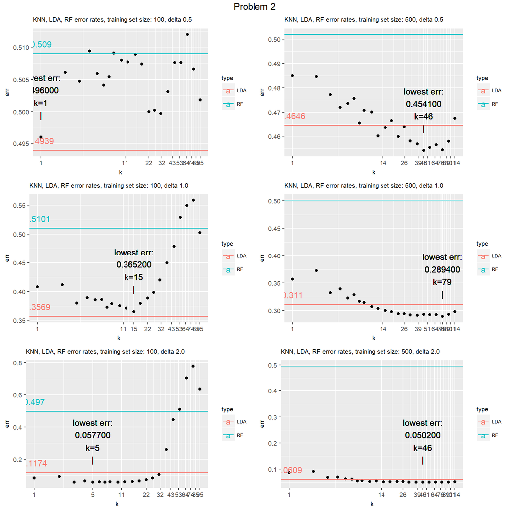

```r
tny_theme= theme(
  text = element_text(size=8),
  plot.title = element_text(size=8),
  axis.title.x = element_text(size=8),
  axis.text.x = element_text(size=8),
  axis.title.y = element_text(size=8),
  axis.text.y = element_text(size=8)
)

library("gridExtra")
grid.arrange(out1$g_plot+tny_theme, out2$g_plot+tny_theme, out3$g_plot+tny_theme, out4$g_plot+tny_theme, out5$g_plot+tny_theme, out6$g_plot+tny_theme, nrow=3, ncol=2, top='Problem 2')
```

# Sub-problem 3 (15 points): varying counts of predictors

For all possible pairwise combinations of the numbers of variables associated with outcome (`nClassVars=2` and `5`) and those not associated with the outcome (`nNoiseVars=1`, `3` and `10`) – six pairwise combinations in total – obtain and present graphically test errors from random forest, LDA and KNN. Choose signal magnitude (`deltaClass`) and training data sample size so that this simulation yields non-trivial results – noticeable variability in the error rates across those six pairwise combinations of attribute counts. Describe the results: what is the impact of the increase of the number of attributes associated with the outcome on the classifier performance? What about the number of attributes not associated with outcome - does it affect classifier error rate? Are different classifier methods affected by these simulation parameters in a similar way?

> For all possible pairwise combinations of the numbers of variables associated with outcome (`nClassVars=2` and `5`) and those not associated with the outcome (`nNoiseVars=1`, `3` and `10`) – six pairwise combinations in total – obtain and present graphically test errors from random forest, LDA and KNN. Choose signal magnitude (`deltaClass`) and training data sample size so that this simulation yields non-trivial results – noticeable variability in the error rates across those six pairwise combinations of attribute counts.

I tried a few different combinations of training set size and `delta` values on the set of 6 combinations and a train size of 100 and `delta`=1 seemed to produce pretty decent variable across the results

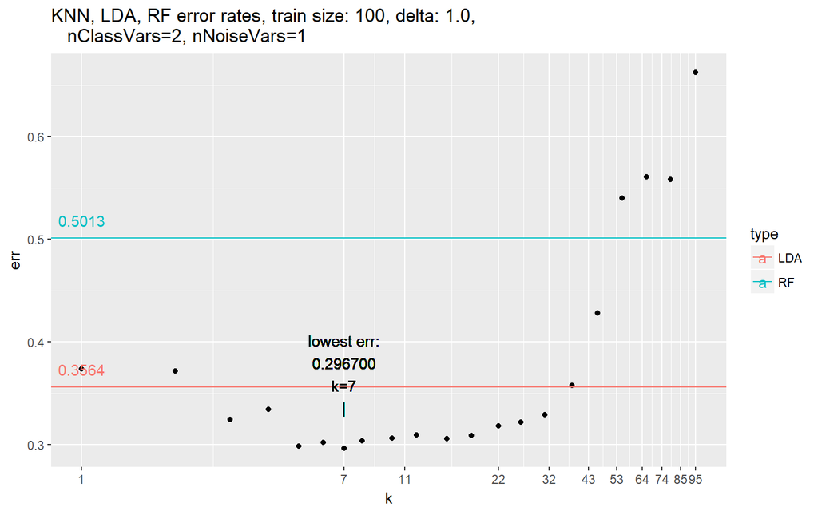

```r
train_size = 100
delta_val = 1

# generate data: 2 predictors associated with outcome, 1/3/10 noiseVars
train_2class_1noise = sim_data(nObs=train_size, deltaClass=delta_val, nClassVars=2, nNoiseVars=1)
test_2class_1noise = sim_data(nObs=10000, deltaClass=delta_val, nClassVars=2, nNoiseVars=1)
train_2class_3noise = sim_data(nObs=train_size, deltaClass=delta_val, nClassVars=2, nNoiseVars=3)
test_2class_3noise = sim_data(nObs=1000, deltaClass=delta_val, nClassVars=2, nNoiseVars=3)
train_2class_10noise = sim_data(nObs=train_size, deltaClass=delta_val, nClassVars=2, nNoiseVars=10)
test_2class_10noise = sim_data(nObs=1000, deltaClass=delta_val, nClassVars=2, nNoiseVars=10)


# generate data: 5 predictors associated with outcome, 1/3/10 noiseVars
train_5class_1noise = sim_data(nObs=train_size, deltaClass=delta_val, nClassVars=5, nNoiseVars=1)
test_5class_1noise = sim_data(nObs=10000, deltaClass=delta_val, nClassVars=5, nNoiseVars=1)
train_5class_3noise = sim_data(nObs=train_size, deltaClass=delta_val, nClassVars=5, nNoiseVars=3)
test_5class_3noise = sim_data(nObs=1000, deltaClass=delta_val, nClassVars=5, nNoiseVars=3)
train_5class_10noise = sim_data(nObs=train_size, deltaClass=delta_val, nClassVars=5, nNoiseVars=10)
test_5class_10noise = sim_data(nObs=1000, deltaClass=delta_val, nClassVars=5, nNoiseVars=10)


# create plots: 2 predictors associated with outcome, 1/3/10 noiseVars
rf_2class_1noise = rf_predict_table(train_2class_1noise, test_2class_1noise)
lda_2class_1noise = lda_predict_table(train_2class_1noise, test_2class_1noise)
rng = sort(unique(floor(1.2^(1:26))))
df_knn_2class_1noise = knn_predict_multiple(train_2class_1noise, test_2class_1noise, knn_range=rng)
out1 = get_err_plot(df_knn_2class_1noise, rf_2class_1noise$err_rate, lda_2class_1noise$err_rate,
  sprintf('train size: %d, delta: %.1f, \n   nClassVars=%d, nNoiseVars=%d', train_size, delta_val, 2, 1))
#knn_2class_1noise_err_info=out1$err_info


rf_2class_3noise = rf_predict_table(train_2class_3noise, test_2class_3noise)
lda_2class_3noise = lda_predict_table(train_2class_3noise, test_2class_3noise)
rng = sort(unique(floor(1.2^(1:26))))
df_knn_2class_3noise = knn_predict_multiple(train_2class_3noise, test_2class_3noise, knn_range=rng)
out2 = get_err_plot(df_knn_2class_3noise, rf_2class_3noise$err_rate, lda_2class_3noise$err_rate,
  sprintf('train size: %d, delta: %.1f, \n   nClassVars=%d, nNoiseVars=%d', train_size, delta_val, 2, 3))
#knn_2class_1noise_err_info=out2$err_info


rf_2class_10noise = rf_predict_table(train_2class_10noise, test_2class_10noise)
lda_2class_10noise = lda_predict_table(train_2class_10noise, test_2class_10noise)
rng = sort(unique(floor(1.2^(1:26))))
df_knn_2class_10noise = knn_predict_multiple(train_2class_10noise, test_2class_10noise, knn_range=rng)
out3 = get_err_plot(df_knn_2class_10noise, rf_2class_10noise$err_rate, lda_2class_10noise$err_rate,
  sprintf('train size: %d, delta: %.1f, \n   nClassVars=%d, nNoiseVars=%d', train_size, delta_val, 2, 10))
#knn_2class_1noise_err_info=out2$err_info


# create plots: 5 predictors associated with outcome, 1/3/10 noiseVars
rf_5class_1noise = rf_predict_table(train_5class_1noise, test_5class_1noise)
lda_5class_1noise = lda_predict_table(train_5class_1noise, test_5class_1noise)
rng = sort(unique(floor(1.2^(1:26))))
df_knn_5class_1noise = knn_predict_multiple(train_5class_1noise, test_5class_1noise, knn_range=rng)
out4 = get_err_plot(df_knn_5class_1noise, rf_5class_1noise$err_rate, lda_5class_1noise$err_rate,
  sprintf('train size: %d, delta: %.1f, \n   nClassVars=%d, nNoiseVars=%d', train_size, delta_val, 5, 1))
#knn_5class_1noise_err_info=out1$err_info

rf_5class_3noise = rf_predict_table(train_5class_3noise, test_5class_3noise)
lda_5class_3noise = lda_predict_table(train_5class_3noise, test_5class_3noise)
rng = sort(unique(floor(1.2^(1:26))))
df_knn_5class_3noise = knn_predict_multiple(train_5class_3noise, test_5class_3noise, knn_range=rng)
out5 = get_err_plot(df_knn_5class_3noise, rf_5class_3noise$err_rate, lda_5class_3noise$err_rate,
  sprintf('train size: %d, delta: %.1f, \n   nClassVars=%d, nNoiseVars=%d', train_size, delta_val, 5, 3))
#knn_5class_1noise_err_info=out5$err_info


rf_5class_10noise = rf_predict_table(train_5class_10noise, test_5class_10noise)
lda_5class_10noise = lda_predict_table(train_5class_10noise, test_5class_10noise)
rng = sort(unique(floor(1.2^(1:26))))
df_knn_5class_10noise = knn_predict_multiple(train_5class_10noise, test_5class_10noise, knn_range=rng)
out6 = get_err_plot(df_knn_5class_10noise, rf_5class_10noise$err_rate, lda_5class_10noise$err_rate,
  sprintf('train size: %d, delta: %.1f, \n  nClassVars=%d, nNoiseVars=%d', train_size, delta_val, 5, 10))
#knn_5class_1noise_err_info=out5$err_info


out1$g_plot
```

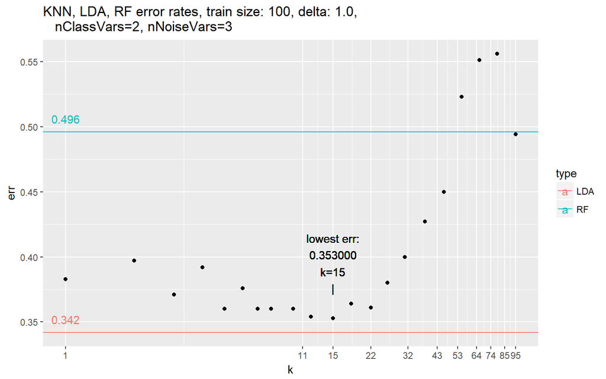

```r
out2$g_plot
```

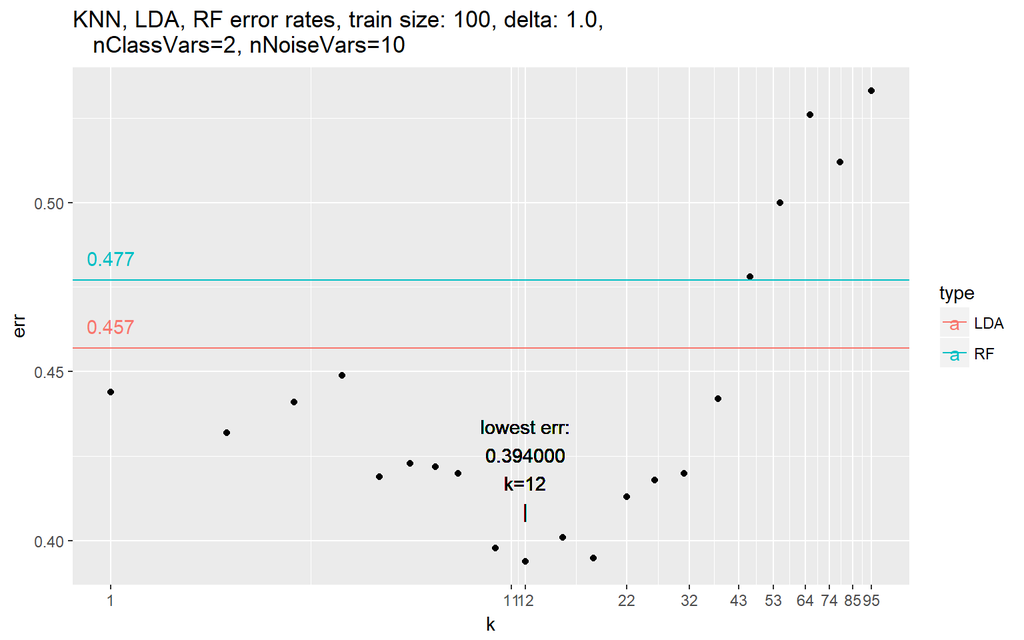

```r
out3$g_plot
```

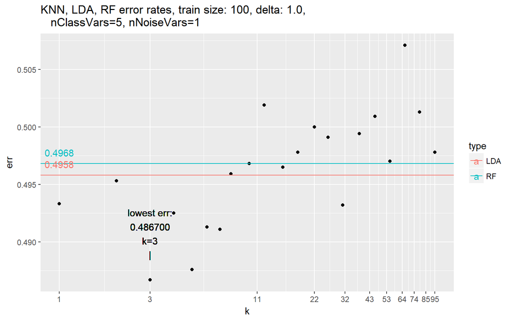

```r
out4$g_plot
```

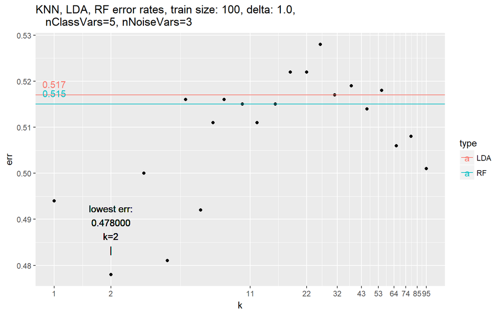

```r
out5$g_plot
```

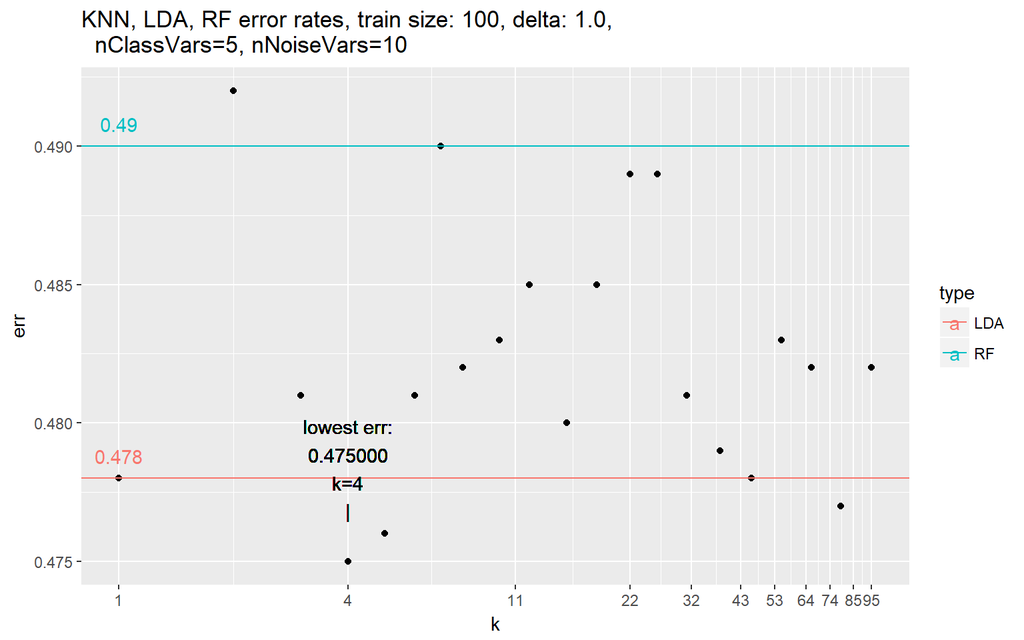

```r
out6$g_plot
```

And all six together

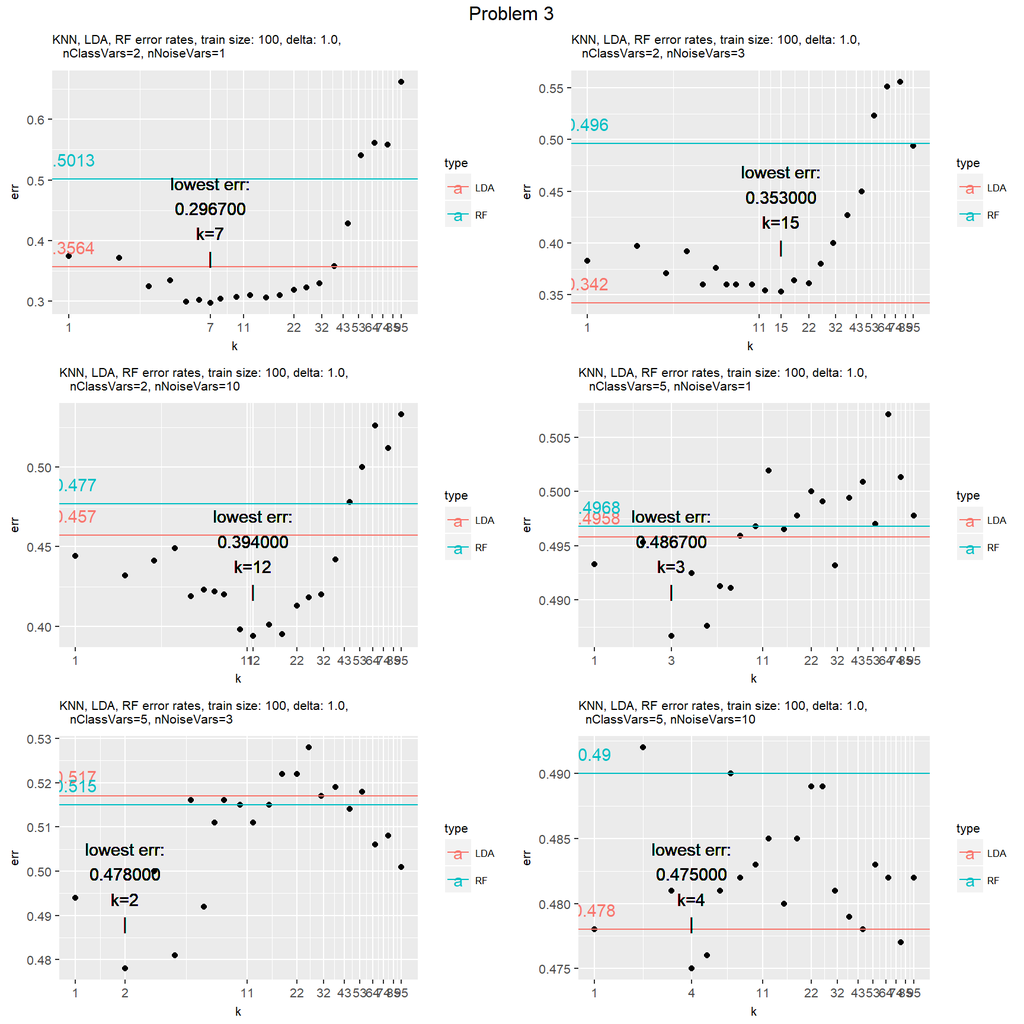

```r
grid.arrange(out1$g_plot+tny_theme, out2$g_plot+tny_theme, out3$g_plot+tny_theme, out4$g_plot+tny_theme, out5$g_plot+tny_theme, out6$g_plot+tny_theme, nrow=3, ncol=2, top='Problem 3')
```

> Describe the results: what is the impact of the increase of the number of attributes associated with the outcome on the classifier performance?

> Are different classifier methods affected by these simulation parameters in a similar way?

As described above the results generally seemed consistent when looking at changes in number of nClassVars (more of those generally increased error rates) and then really a lack of any consistent pattern when looking at number of noise variables across the three methods.

## PROBLEM 3 POSTSCRIPT

The above results didn’t really match my expectations - at the least I was expecting the error rate to go down significantly as more attributes associated with the outcome were added. The pairwise plots I ran on the train sets didn’t make intuitive sense either, but I didn’t have time to look any further until the entire homework was complete (and even then, won’t be able to do more than present the suspicious plots).

Both examples use code straight from the introduction, with only the base variables changed, both producing 5 total predictor variables as in the problem above.

Using a dataset of 1,000 + `nClassVars=2` + `nNoiseVars=3` + `deltaClass=2` (to rev up the signal)

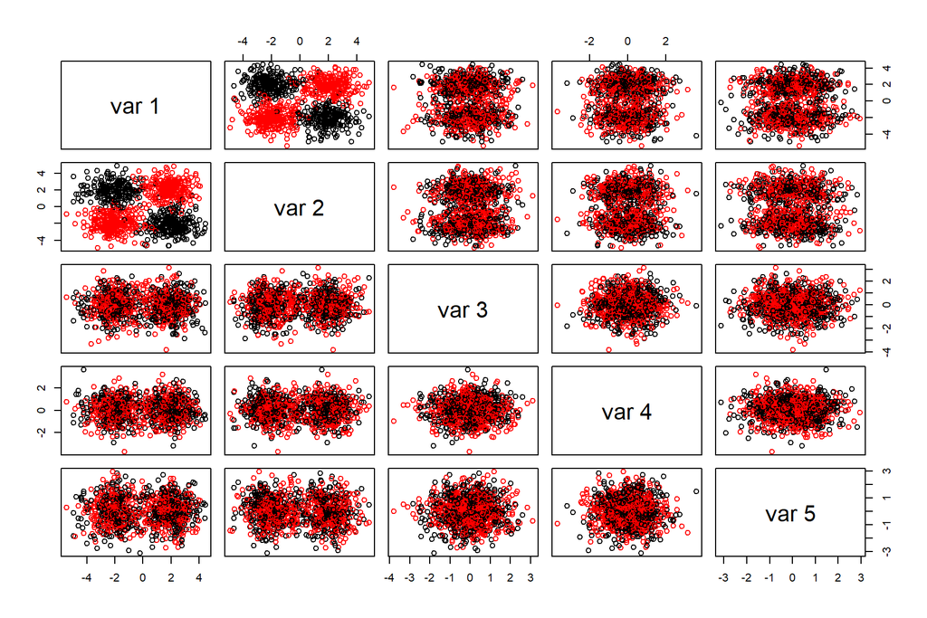

```r
nObs <- 1000
# How many predictors are associated with outcome:
nClassVars <- 2
# How many predictors are not:
nNoiseVars <- 3
# To modulate average difference between two classes' predictor values:
deltaClass <- 2
# Simulate dataset with interaction between attribute levels associated with the outcome:
xyzTmp <- matrix(rnorm(nObs*(nClassVars+nNoiseVars)),nrow=nObs,ncol=nClassVars+nNoiseVars)
classTmp <- 1
for ( iTmp in 1:nClassVars ) {
  deltaTmp <- sample(deltaClass*c(-1,1),nObs,replace=TRUE)
  xyzTmp[,iTmp] <- xyzTmp[,iTmp] + deltaTmp
  #ORIG: classTmp <- classTmp * deltaTmp
  classTmp <- classTmp * deltaTmp
}
classTmp <- factor(classTmp > 0)
#table(classTmp)
pairs(xyzTmp,col=as.numeric(classTmp))
```

A very distinct display of how both **var 1** and **var 2** are tied to outcome, i.e. `nClassVars=2`, very well defined color (class value) clusters.

Next, 1,000 observations again but `nClassVars=3` + `nNoiseVars=2` + `deltaClass=2` (one more “class var”, one fewer noise var)

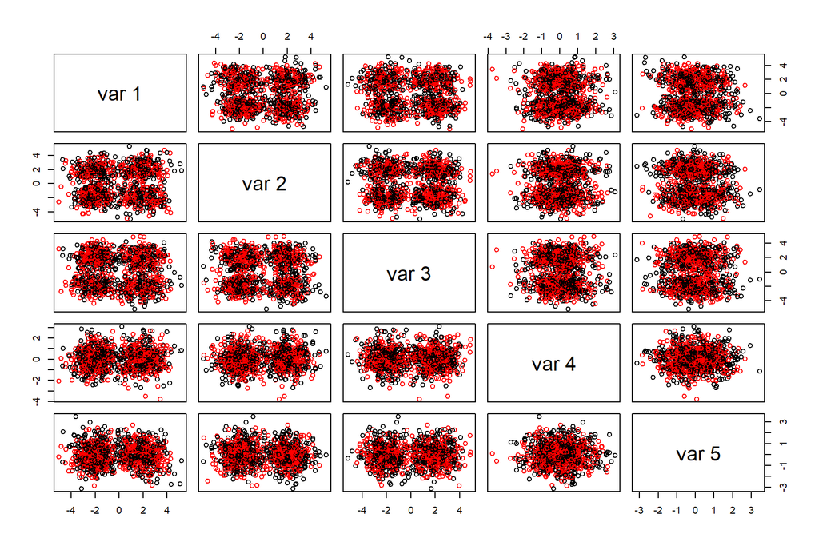

```r
nObs <- 1000
# How many predictors are associated with outcome:
nClassVars <- 3
# How many predictors are not:
nNoiseVars <- 2
# To modulate average difference between two classes' predictor values:
deltaClass <- 2
# Simulate dataset with interaction between attribute levels associated with the outcome:
xyzTmp <- matrix(rnorm(nObs*(nClassVars+nNoiseVars)),nrow=nObs,ncol=nClassVars+nNoiseVars)
classTmp <- 1
for ( iTmp in 1:nClassVars ) {
  deltaTmp <- sample(deltaClass*c(-1,1),nObs,replace=TRUE)
  xyzTmp[,iTmp] <- xyzTmp[,iTmp] + deltaTmp
  #ORIG: classTmp <- classTmp * deltaTmp
  classTmp <- classTmp * deltaTmp
}
classTmp <- factor(classTmp > 0)
#table(classTmp)
pairs(xyzTmp,col=as.numeric(classTmp))
```

My (naive?) expectation was that the colors would continue to be well-defined for **var 1**, **var 2**, and that **var 3** pairings on those first two would also show the color separation. Obviously that didn’t happen…

# Sub-problem 4: (15 points): effect of **mtry**

Parameter `mtry` in the call to `randomForest` defines the number of predictors randomly chosen to be evaluated for their association with the outcome at each split (please see help page for `randomForest` for more details). By default for classification problem it is set as a square root of the number of predictors in the dataset. Here we will evaluate the impact of using different values of `mtry` on the error rate by random forest.

For `nObs=5000`, `deltaClass=2`, `nClassVars=3` and `nNoiseVars=20` generate data using the above approach, run `randomForest` on it with `mtry=2`, `5` and `10` and obtain corresponding test error for these three models. Describe the impact of using different values of `mtry` on the test error rate by random forest and compare it to that by LDA/KNN.

> For `nObs=5000`, `deltaClass=2`, `nClassVars=3` and `nNoiseVars=20` generate data using the above approach, run `randomForest` on it with `mtry=2`, `5` and `10` and obtain corresponding test error for these three models.

Begin by creating the train/test sets, train are at the new `nObs=5000` while the test set remains at 10,000. Next create a model based on Random Forest defaults, and then new ones for each of the described `mtry` levels. Printout includes confidence tables for each + error rates.

```r
train_p4 = sim_data(nObs=5000, deltaClass=2, nClassVars=3, nNoiseVars=20)
test_p4 = sim_data(nObs=10000, deltaClass=2, nClassVars=3, nNoiseVars=20)

rf_p4_mtry_default = rf_predict_table(train_p4, test_p4)
rf_p4_mtry_default
```

```
## $conf_table
##
##         FALSE TRUE
##   FALSE  3179 1782
##   TRUE   1914 3125
##
## $err_rate
## [1] 0.3696
```

```r
rf_p4_mtry2 = rf_predict_table(train_p4, test_p4, mtry_val=2)
```

```
## [1] "mtry passed in = 2"
```

```r
rf_p4_mtry2
```

```
## $conf_table
##
##         FALSE TRUE
##   FALSE  2935 2026
##   TRUE   2062 2977
##
## $err_rate
## [1] 0.4088
```

```r
rf_p4_mtry5 = rf_predict_table(train_p4, test_p4, mtry_val=5)
```

```
## [1] "mtry passed in = 5"
```

```r
rf_p4_mtry5
```

```
## $conf_table
##
##         FALSE TRUE
##   FALSE  3143 1818
##   TRUE   1841 3198
##
## $err_rate
## [1] 0.3659
```

```r
rf_p4_mtry10 = rf_predict_table(train_p4, test_p4, mtry_val=10)
```

```
## [1] "mtry passed in = 10"
```

```r
rf_p4_mtry10
```

```
## $conf_table
##
##         FALSE TRUE
##   FALSE  3454 1507
##   TRUE   1582 3457
##
## $err_rate
## [1] 0.3089
```

> Describe the impact of using different values of `mtry` on the test error rate by random forest and compare it to that by LDA/KNN.

Create the LDA and KNN models

```r
lda_p4 = lda_predict_table(train_p4, test_p4)
rng = sort(unique(floor(1.2^(1:28))))
df_knn_p4 = knn_predict_multiple(train_p4, test_p4, knn_range=rng)
```

And present the results

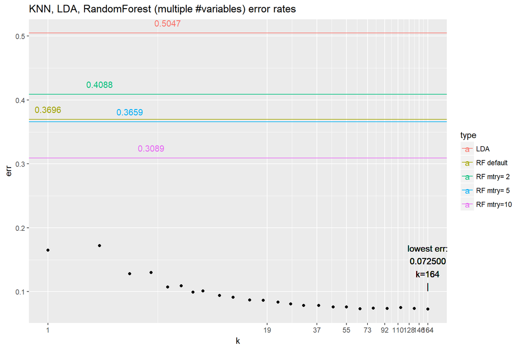

```r
err_lines = c(rf_p4_mtry_default$err_rate, rf_p4_mtry2$err_rate, rf_p4_mtry5$err_rate, rf_p4_mtry10$err_rate, lda_p4$err_rate)
data_df = data.frame(type=c('RF default','RF mtry= 2', 'RF mtry= 5', 'RF mtry=10', 'LDA'),
                     err=err_lines,
                     x_pos=1:5)

plt_ok = (ggplot(df_knn_p4,aes(x=k,y=err))
       + geom_point()+scale_x_log10()
       + geom_hline(aes(yintercept = err, colour=type), data=data_df)
       + ggtitle("KNN error rate "))

lowest_err_row = df_knn_p4[which(df_knn_p4$err==min(df_knn_p4$err)),][1,]
lowest_err_value = round(lowest_err_row$err, 4)
lowest_err_k = lowest_err_row$k
lowest_err_label = sprintf('lowest err:\n%f\nk=%d', lowest_err_row$err, lowest_err_k)

plt = (ggplot(df_knn_p4,aes(x=k,y=err))
  + geom_point()
  + scale_x_log10(breaks=sort(c(round(seq(min(df_knn_p4$k), max(df_knn_p4$k), length.out=10)), lowest_err_k)))
  + geom_hline(aes(yintercept = err, colour=type), data=data_df)
  + geom_text(aes(x=x_pos, err, colour=type, label=err, vjust = -1), data=data_df)
  + geom_text(aes(lowest_err_k, lowest_err_value, label=lowest_err_label, vjust=-1))
  + geom_text(aes(lowest_err_k, lowest_err_value, label='|', vjust=-3))
  + ggtitle("KNN, LDA, RandomForest (multiple #variables) error rates"))

plt
```

Once again LDA is producing the worst error rate, by a fair margin, and also once again KNN is returning the lowest error rate, at a relatively high level of $K$.